# Time Series Model for Housing Starts for the USA Using Python and ARIMA

### September 2, 2020

Template Credit: Adapted from a template made available by Dr. Jason Brownlee of Machine Learning Mastery. https://machinelearningmastery.com/

SUMMARY: The purpose of this project is to construct a time series prediction model and document the end-to-end steps using a template. The Housing Starts in the USA dataset is a time series situation where we are trying to forecast future outcomes based on past data points.

ANALYSIS: The baseline prediction (or persistence) for the dataset resulted in an RMSE of 9.705. After performing a grid search for the most optimal ARIMA parameters, the final ARIMA non-seasonal order was (4, 0, 4) with the seasonal order being (1, 0, 2, 12). Furthermore, the chosen model processed the validation data with an RMSE of 8.763, which was better than the baseline model as expected.

CONCLUSION: For this dataset, the chosen ARIMA model achieved a satisfactory result, and we should consider using the algorithm for further modeling.

Dataset Used: Housing Starts: Total: New Privately Owned Housing Units Started, U.S. Census Bureau and U.S. Department of Housing and Urban Development, Housing Starts: Total: New Privately Owned Housing Units Started [HOUSTNSA], retrieved from FRED, Federal Reserve Bank of St. Louis; https://fred.stlouisfed.org/series/HOUSTNSA, August 23, 2020.

Dataset ML Model: Time series forecast with numerical attribute

A time series predictive modeling project generally can be broken down into about five major tasks:

1. Define Problem and Acquire Data
2. Inspect and Explore Data
3. Clean and Pre-Process Data
4. Fit and Evaluate Models
5. Finalize Model and Make Predictions

## Task 1: Define Problem and Acquire Data

```python
# Install the necessary packages for Colab
# !pip install python-dotenv PyMySQL
```

```python
# Retrieve the GPU information from Colab
# gpu_info = !nvidia-smi
# gpu_info = '\n'.join(gpu_info)
# if gpu_info.find('failed') >= 0:
#     print('Select the Runtime → "Change runtime type" menu to enable a GPU accelerator, ')
#     print('and then re-execute this cell.')
# else:
#     print(gpu_info)
```

```python
# Retrieve the memory configuration from Colab
# from psutil import virtual_memory
# ram_gb = virtual_memory().total / 1e9
# print('Your runtime has {:.1f} gigabytes of available RAM\n'.format(ram_gb))

# if ram_gb < 20:
#     print('To enable a high-RAM runtime, select the Runtime → "Change runtime type"')
#     print('menu, and then select High-RAM in the Runtime shape dropdown. Then, ')
#     print('re-execute this cell.')
# else:
#     print('You are using a high-RAM runtime!')
```

```python
# Retrieve the CPU information
ncpu = !nproc
print("The number of available CPUs is:", ncpu[0])
```

```
The number of available CPUs is: 4
```

### 1.a) Load Libraries

```python
# Create the random seed number for reproducible results
seedNum = 888
```

```python
import pandas as pd
import matplotlib.pyplot as plt
import seaborn as sns
import pmdarima as pm
import os
import sys
import math
import boto3
from datetime import datetime
from sklearn.metrics import mean_squared_error
from statsmodels.tsa.statespace.sarimax import SARIMAX
from statsmodels.tsa.stattools import adfuller
from statsmodels.tsa.seasonal import seasonal_decompose
from statsmodels.graphics.tsaplots import plot_acf
from statsmodels.graphics.tsaplots import plot_pacf
import pandas_datareader.data as web
```

### 1.b) Set up the controlling parameters and functions

```python
# Begin the timer for the script processing
startTimeScript = datetime.now()

# Set up the number of CPU cores available for multi-thread processing
n_jobs = 2

# Set up the flag to stop sending progress emails (setting to True will send status emails!)
notifyStatus = False

# Set up the parent directory location for loading the dotenv files
useGDrive = False
if useGDrive:
    # Mount Google Drive locally for storing files
    from google.colab import drive
    drive.mount('/content/gdrive')
    gdrivePrefix = '/content/gdrive/My Drive/Colab_Downloads/'
    env_path = '/content/gdrive/My Drive/Colab Notebooks/'
    dotenv_path = env_path + "python_script.env"
    load_dotenv(dotenv_path=dotenv_path)

# Set up the dotenv file for retrieving environment variables
useLocalPC = False
if useLocalPC:
    env_path = "/Users/david/PycharmProjects/"
    dotenv_path = env_path + "python_script.env"
    load_dotenv(dotenv_path=dotenv_path)

# Configure the plotting style
plt.style.use('seaborn')

# Set Pandas options
pd.set_option("display.max_rows", 500)
pd.set_option("display.width", 140)
```

```python
# Set up the email notification function
def status_notify(msg_text):
    access_key = os.environ.get('SNS_ACCESS_KEY')
    secret_key = os.environ.get('SNS_SECRET_KEY')
    aws_region = os.environ.get('SNS_AWS_REGION')
    topic_arn = os.environ.get('SNS_TOPIC_ARN')
    if (access_key is None) or (secret_key is None) or (aws_region is None):
        sys.exit("Incomplete notification setup info. Script Processing Aborted!!!")
    sns = boto3.client('sns', aws_access_key_id=access_key, aws_secret_access_key=secret_key, region_name=aws_region)
    response = sns.publish(TopicArn=topic_arn, Message=msg_text)
    if response['ResponseMetadata']['HTTPStatusCode'] != 200 :
        print('Status notification not OK with HTTP status code:', response['ResponseMetadata']['HTTPStatusCode'])
```

```python
if notifyStatus: status_notify("ARIMA Task 1: Define Problem and Acquire Data has begun! "+datetime.now().strftime('%a %B %d, %Y %I:%M:%S %p'))
```

### 1.c) Acquire and Load the Data

```python
# load the dataset and the necessary data structure
# time_series = pd.read_csv('https://dainesanalytics.com/datasets/time-series-data-library/tsdl444.csv', index_col='idx', parse_dates=True)

# Load the dataset from the Federal Reserve Bank's FRED Database
starting = datetime(1959, 1, 1)
ending = datetime.now()
fred_data = 'HOUSTNSA'
time_series = web.DataReader(fred_data, 'fred', starting, ending)
time_series.rename(columns={fred_data: 'value'}, inplace=True)

# Sample code for subsetting the time-series data
# time_series = original_series['1986':'1990']
```

```python
target_col = time_series.columns[0]
lower_bound = 'lower ' + target_col
upper_bound = 'upper ' + target_col
print('The target column of the time series is:', target_col)
print('The forecast boundary columns are:', lower_bound, '&', upper_bound)
```

```
The target column of the time series is: value
The forecast boundary columns are: lower value & upper value
```

```python
time_series.info(verbose=True)
```

```
<class 'pandas.core.frame.DataFrame'>
DatetimeIndex: 739 entries, 1959-01-01 to 2020-07-01
Data columns (total 1 columns):
 #   Column  Non-Null Count  Dtype
---  ------  --------------  -----
 0   value   739 non-null    float64
dtypes: float64(1)
memory usage: 11.5 KB
```

```python
time_series.head(10)
```

| DATE | value |
| --- | --- |
| 1959-01-01 | 96.2 |
| 1959-02-01 | 99.0 |
| 1959-03-01 | 127.7 |
| 1959-04-01 | 150.8 |
| 1959-05-01 | 152.5 |
| 1959-06-01 | 147.8 |
| 1959-07-01 | 148.1 |
| 1959-08-01 | 138.2 |
| 1959-09-01 | 136.4 |
| 1959-10-01 | 120.0 |

```python
time_series.tail(10)
```

| DATE | value |
| --- | --- |
| 2019-10-01 | 114.8 |
| 2019-11-01 | 103.4 |
| 2019-12-01 | 108.3 |
| 2020-01-01 | 113.1 |
| 2020-02-01 | 111.6 |
| 2020-03-01 | 104.5 |
| 2020-04-01 | 84.9 |
| 2020-05-01 | 95.1 |
| 2020-06-01 | 114.6 |
| 2020-07-01 | 139.4 |

```python
if notifyStatus: status_notify("ARIMA Task 1: Define Problem and Acquire Data completed! "+datetime.now().strftime('%a %B %d, %Y %I:%M:%S %p'))
```

## Task 2: Inspect and Explore Data

```python
if notifyStatus: status_notify("ARIMA Task 2: Inspect and Explore Data has begun! "+datetime.now().strftime('%a %B %d, %Y %I:%M:%S %p'))
```

### 2.a) Summary Statistics of the Time Series Data

Summary statistics provide a quick look at the limits of observed values. It can help to get a quick idea of what we are working with.

```python
# Summary statistics of time series
print(time_series.describe())
```

```
            value
count  739.000000
mean   119.015020
std     38.309415
min     31.900000
25%     91.400000
50%    117.800000
75%    144.950000
max    234.000000
```

### 2.b) Line Plot of the Time Series Data

A line plot of a time series can provide a lot of insight into the problem. Some observations from the plot can include:

- Whether the trend appears to be level around the mean
- Whether there appear to be any obvious outliers

The ARIMA(p,d,q) model requires three parameters and assumes that we are working with a stationary time series.

The ADF results should show that the test statistic value is smaller than the critical value at 5% if the time series is stationary. This suggests that we can reject the null hypothesis (i.e. a low probability that the result is a statistical fluke).

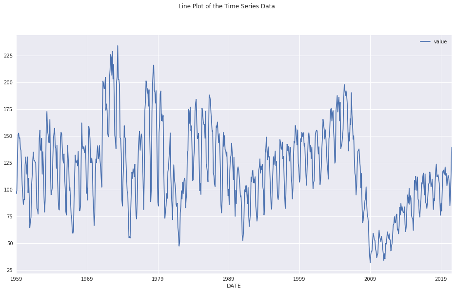

```python
# Line plots of time series
fig, ax = plt.subplots(figsize=(16,9))
fig.suptitle('Line Plot of the Time Series Data')
time_series.plot(ax=ax)
plt.show()
```

### 2.c) Histogram and Density Plots of the Time Series Data

Reviewing plots of the density of observations can provide further insight into the structure of the data. Some observations from the plots can include:

- Whether the distribution is Gaussian
- Whether the distribution has a long tail and may suggest the need for data transformation

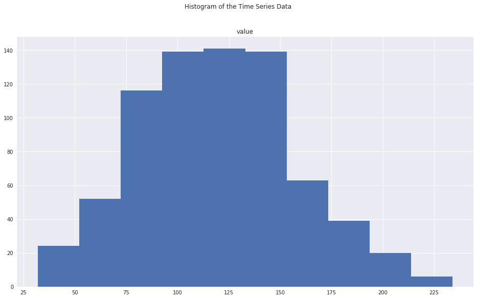

```python
# Line plots of time series
fig, ax = plt.subplots(figsize=(16,9))
fig.suptitle('Histogram of the Time Series Data')
time_series.hist(ax=ax)
plt.show()
```

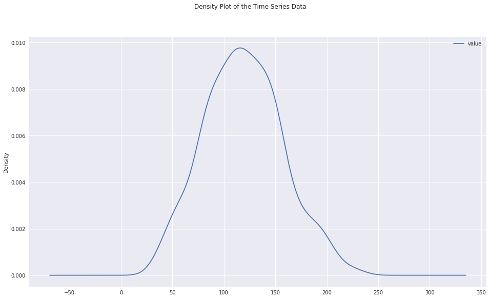

```python
# Line plots of time series
fig, ax = plt.subplots(figsize=(16,9))
fig.suptitle('Density Plot of the Time Series Data')
time_series.plot(kind='kde', ax=ax)
plt.show()
```

### 2.d) Box and Whisker Plots of the Time Series Data

We can group or aggregate the data and get a better idea of the spread of observations. Some observations from reviewing the plot can include:

- Whether the median values for each grouping shows any significant trend
- Whether the spread, or middle 50% of the data, shows any significant variability
- Whether there are outliers in some grouping

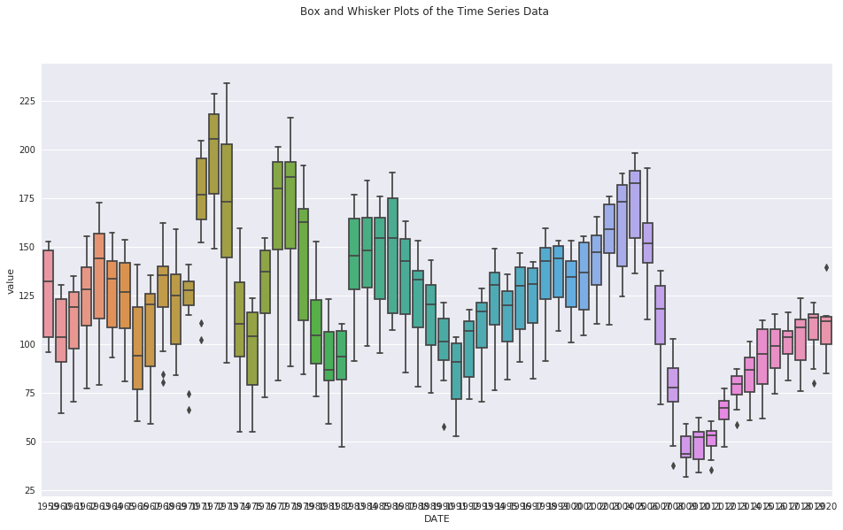

```python
# boxplots of time series
fig, ax = plt.subplots(figsize=(16,9))
fig.suptitle('Box and Whisker Plots of the Time Series Data')
squeezed = time_series.squeeze()
# sns.boxplot(squeezed.index.year, squeezed, ax=ax)
sns.boxplot(squeezed.index.year, squeezed, ax=ax)
plt.show()
```

```python
if notifyStatus: status_notify("ARIMA Task 2: Inspect and Explore Data completed! "+datetime.now().strftime('%a %B %d, %Y %I:%M:%S %p'))
```

## Task 3: Clean and Pre-Process Data

```python
if notifyStatus: status_notify("ARIMA Task 3: Clean and Pre-Process Data has begun! "+datetime.now().strftime('%a %B %d, %Y %I:%M:%S %p'))
```

### Section 3.a) Data Transformation

```python
# Resampling the time series into monthly average for the ease of modeling
# original_series = time_series
# resample = original_series.resample('M')
# time_series = resample.mean()
# time_series.head(10)
```

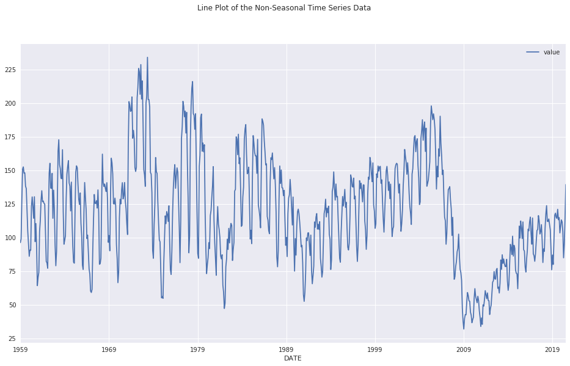

```python
# Line plots of the transformed time series
fig, ax = plt.subplots(figsize=(16,9))
fig.suptitle('Line Plot of the Non-Seasonal Time Series Data')
time_series.plot(ax=ax)
plt.show()
```

### Section 3.b) Test for Stationarity

```python
# Check if stationary
result = adfuller(time_series[target_col])
print('ADF Statistic: %f' % result[0])
print('p-value: %f' % result[1])
print('Critical Test Statistics Values:')
for key, value in result[4].items():
    print('\t%s: %.3f' % (key, value))
```

```
ADF Statistic: -4.085412
p-value: 0.001024
Critical Test Statistics Values:
	1%: -3.439
	5%: -2.866
	10%: -2.569
```

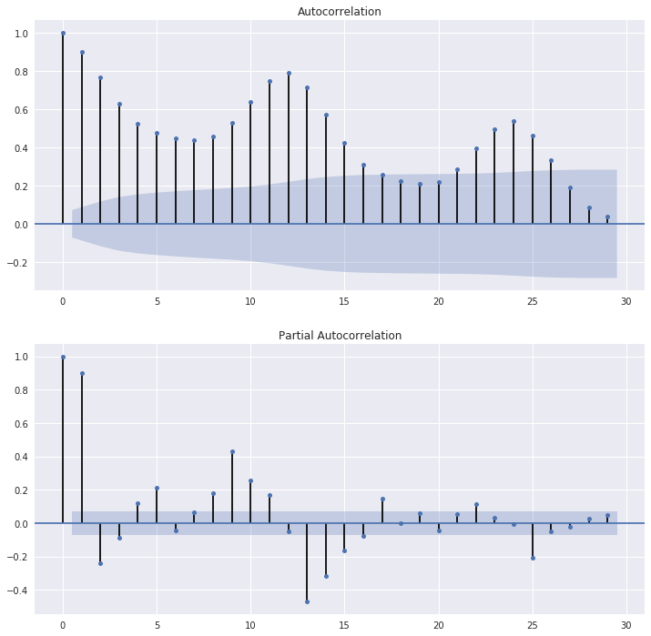

```python
# ACF and PACF plots of the time series data
fig, (ax1, ax2) = plt.subplots(2, 1, figsize=(12,12))
plot_acf(time_series, ax=ax1)
plot_pacf(time_series, ax=ax2)
plt.show()
```

### 3.c) Test for Stationarity of Non-Seasonal Time Series Data

Occasionally a time series may look non-stationary on the first look. We can make it stationary by differencing the series and using a statistical test to confirm that the differenced result is stationary. Rejecting the null hypothesis means that the process has no unit root, and in turn that the time series is stationary or does not have time-dependent structure.

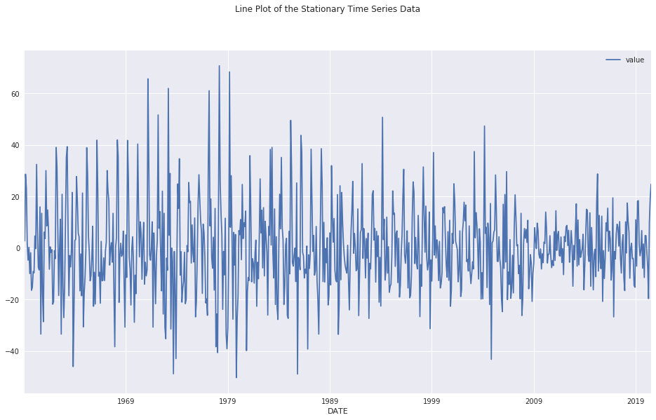

```python
# Create a differenced series
stationary_ns = time_series.diff().dropna()

# Plot differenced data
fig, ax = plt.subplots(figsize=(16,9))
fig.suptitle('Line Plot of the Stationary Time Series Data')
stationary_ns.plot(ax=ax)
plt.show()
```

```python
# Check for stationarity
result = adfuller(stationary_ns[target_col])
print('ADF Statistic: %f' % result[0])
print('p-value: %f' % result[1])
print('Critical Test Statistics Values:')
for key, value in result[4].items():
    print('\t%s: %.3f' % (key, value))
```

```
ADF Statistic: -6.357361
p-value: 0.000000
Critical Test Statistics Values:
	1%: -3.440
	5%: -2.866
	10%: -2.569
```

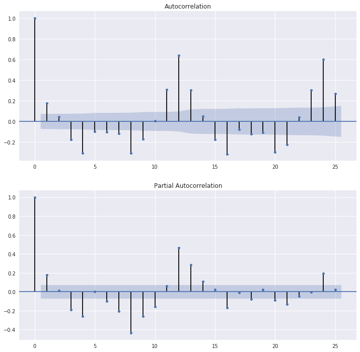

```python
# ACF and PACF plots of the stationary time series
lags = 25
fig, (ax1, ax2) = plt.subplots(2, 1, figsize=(12,12))
plot_acf(stationary_ns, lags=lags, ax=ax1)
plot_pacf(stationary_ns, lags=lags, ax=ax2)
plt.show()
```

### 3.d) Seasonal Decomposition for Seasonal Time Series Data

```python
# Set the initial seasonal frequency parameter
seasonal_freq = 12
```

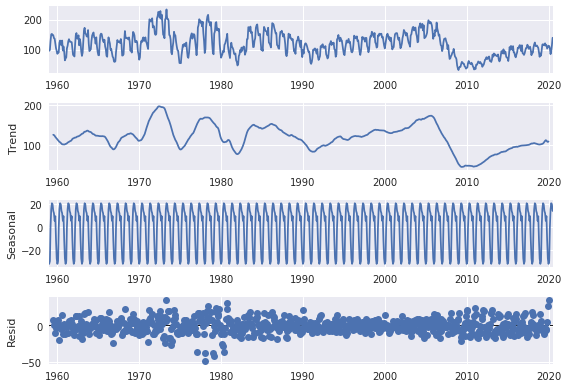

```python
# Perform seasonal decomposition to observe the seasonal frequency
decomp_results = seasonal_decompose(time_series, period=seasonal_freq)
decomp_results.plot()
plt.show()
```

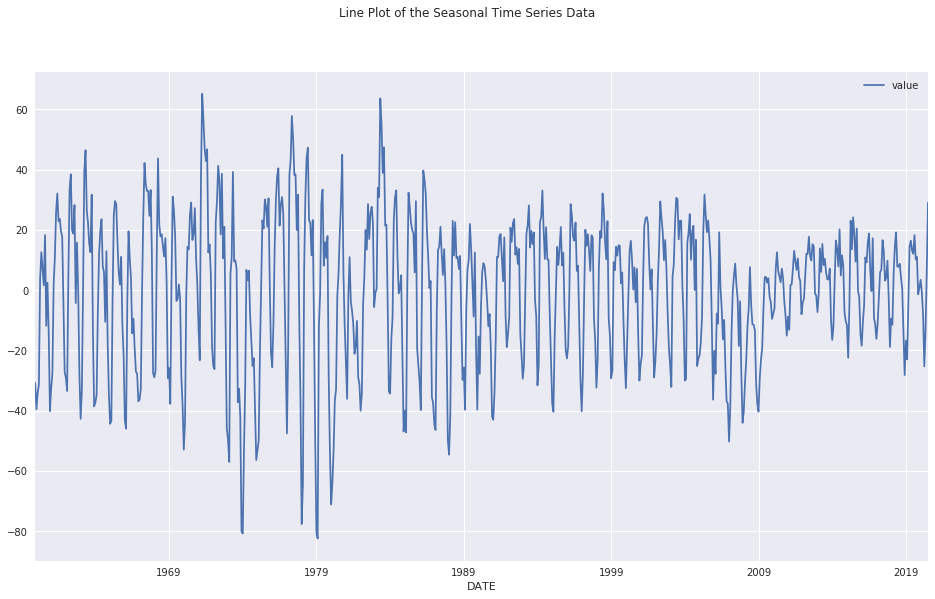

```python
# Create a seasonal series
N = seasonal_freq
seasonal_series = time_series - time_series.rolling(N).mean()
seasonal_series = seasonal_series.dropna()

# Line plots of the seasonal time series
fig, ax = plt.subplots(figsize=(16,9))
fig.suptitle('Line Plot of the Seasonal Time Series Data')
seasonal_series.plot(ax=ax)
plt.show()
```

```python
# Check for stationarity
result = adfuller(seasonal_series[target_col])
print('ADF Statistic: %f' % result[0])
print('p-value: %f' % result[1])
print('Critical Test Statistics Values:')
for key, value in result[4].items():
    print('\t%s: %.3f' % (key, value))
```

```
ADF Statistic: -5.900513
p-value: 0.000000
Critical Test Statistics Values:
	1%: -3.440
	5%: -2.866
	10%: -2.569
```

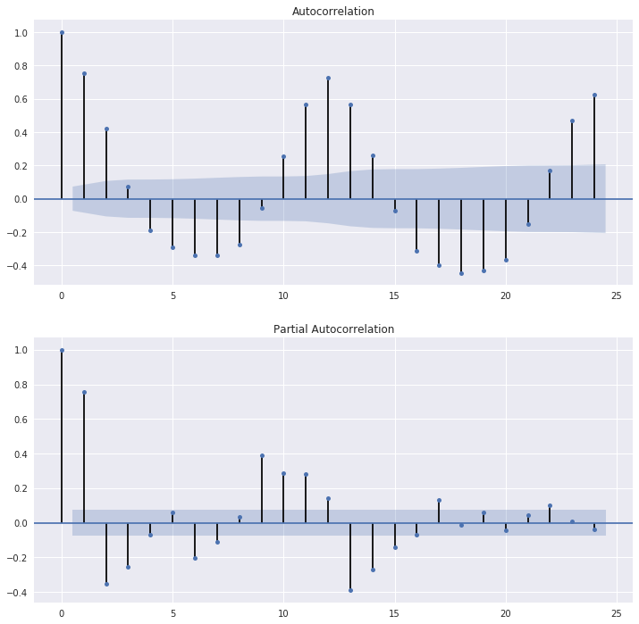

```python
# ACF and PACF plots of the time series data
lag = seasonal_freq * 2
fig, (ax1, ax2) = plt.subplots(2, 1, figsize=(12,12))
plot_acf(seasonal_series, lags=lag, ax=ax1)
plot_pacf(seasonal_series, lags=lag, ax=ax2)
plt.show()
```

### 3.e) Test for Stationarity of Seasonal Time Series Data

Occasionally a time series may look non-stationary on the first look. We can make it stationary by differencing the series and using a statistical test to confirm that the differenced result is stationary. Rejecting the null hypothesis means that the process has no unit root, and in turn that the time series is stationary or does not have time-dependent structure.

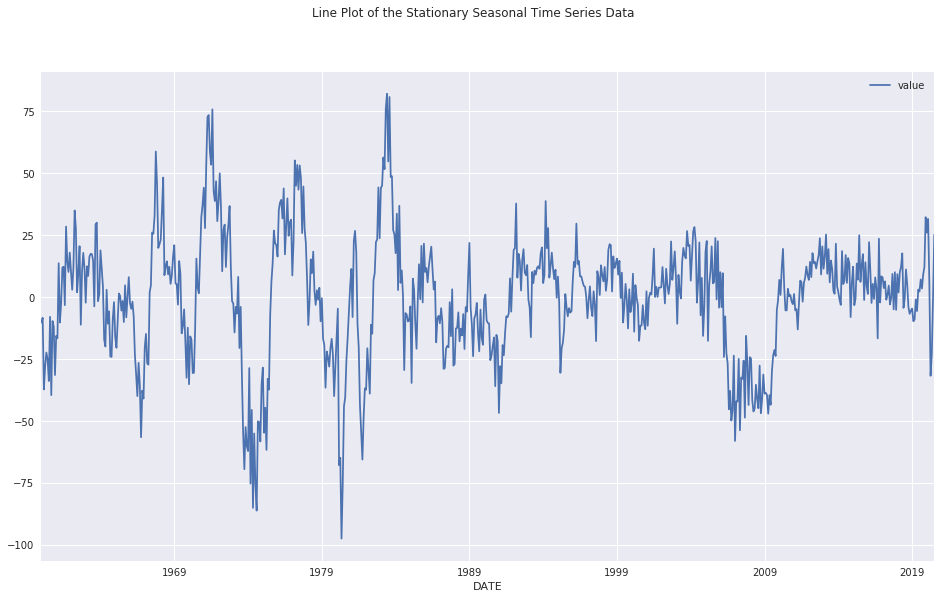

```python
# Create a differenced series
stationary_ss = time_series.diff(seasonal_freq).dropna()

# Plot differenced data
fig, ax = plt.subplots(figsize=(16,9))
fig.suptitle('Line Plot of the Stationary Seasonal Time Series Data')
stationary_ss.plot(ax=ax)
plt.show()
```

```python
# Check for stationarity
result = adfuller(stationary_ss[target_col])
print('ADF Statistic: %f' % result[0])
print('p-value: %f' % result[1])
print('Critical Test Statistics Values:')
for key, value in result[4].items():
    print('\t%s: %.3f' % (key, value))
```

```
ADF Statistic: -5.301227
p-value: 0.000005
Critical Test Statistics Values:
	1%: -3.440
	5%: -2.866
	10%: -2.569
```

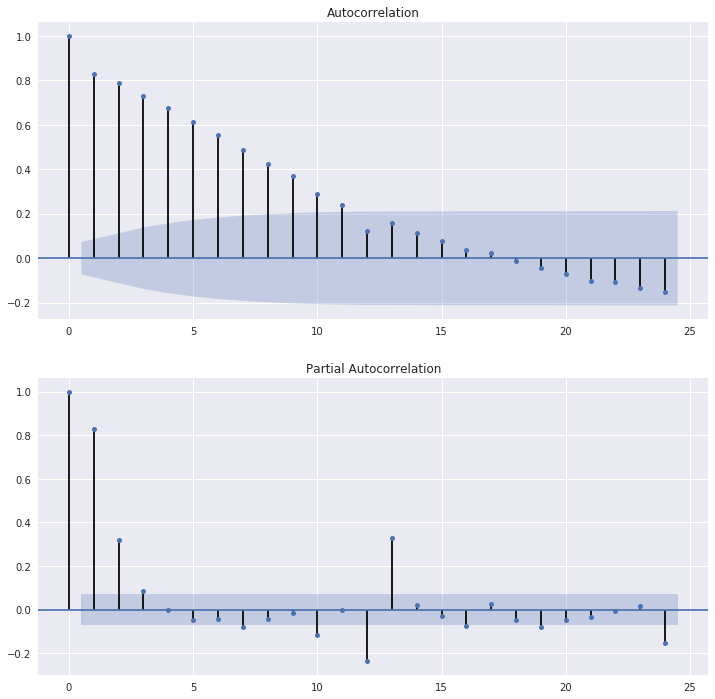

```python
# ACF and PACF plots of the stationary time series
lags = seasonal_freq * 2
fig, (ax1, ax2) = plt.subplots(2, 1, figsize=(12,12))
plot_acf(stationary_ss, lags=lags, ax=ax1)
plot_pacf(stationary_ss, lags=lags, ax=ax2)
plt.show()
```

```python
if notifyStatus: status_notify("ARIMA Task 3: Clean and Pre-Process Data completed! "+datetime.now().strftime('%a %B %d, %Y %I:%M:%S %p'))
```

## Task 4: Fit and Evaluate Models

```python
if notifyStatus: status_notify("ARIMA Task 4: Fit and Evaluate Models has begun! "+datetime.now().strftime('%a %B %d, %Y %I:%M:%S %p'))
```

### 4.a) Establish the Persistent Model

The first step before getting bogged down in data analysis and modeling is to establish a baseline of performance. This will provide both a template for evaluating models using the proposed test harness and a performance measure by which all more elaborate predictive models can be compared.

The baseline prediction for time series forecasting is called the naive forecast, or persistence. This is where the observation from the previous time step is used as the prediction for the observation at the next time step.

#### 4.a.iii) Establish the Persistent Model as Baseline

```python
# Prepare and evaluate a persistence model
X = time_series.values
X = X.astype('float32')
train_pct = 0.80
train_size = int(len(X) * train_pct)
test_size = len(X) - train_size
train_ts, test_ts = X[0:train_size], X[train_size:]

# walk-forward validation
history = [x for x in train_ts]
predictions = list()
for i in range(len(test_ts)):
    yhat = history[-1]
    predictions.append(yhat)
    obs = test_ts[i]
    history.append(obs)
    print('>Predicted=%.3f, Expected=%3.f' % (yhat, obs))

# Calculate performance
rmse = math.sqrt(mean_squared_error(test_ts, predictions))
print('RMSE for the persistent model is: %.3f' % rmse)
```

```
>Predicted=82.200, Expected= 90
>Predicted=89.500, Expected= 92
>Predicted=91.700, Expected=102
>Predicted=102.500, Expected= 87
>Predicted=86.700, Expected= 76
>Predicted=76.400, Expected= 74
>Predicted=73.900, Expected= 68
>Predicted=68.200, Expected= 48
>Predicted=47.500, Expected= 38
>Predicted=37.700, Expected= 32
>Predicted=31.900, Expected= 40
>Predicted=39.800, Expected= 43
>Predicted=42.700, Expected= 42
>Predicted=42.500, Expected= 52
>Predicted=52.200, Expected= 59
>Predicted=59.100, Expected= 57
>Predicted=56.800, Expected= 53
>Predicted=52.900, Expected= 53
>Predicted=52.600, Expected= 44
>Predicted=44.500, Expected= 42
>Predicted=42.300, Expected= 37
>Predicted=36.600, Expected= 39
>Predicted=38.900, Expected= 41
>Predicted=40.700, Expected= 55
>Predicted=54.700, Expected= 62
>Predicted=62.000, Expected= 56
>Predicted=56.200, Expected= 54
>Predicted=53.800, Expected= 52
>Predicted=51.500, Expected= 56
>Predicted=56.300, Expected= 53
>Predicted=53.000, Expected= 45
>Predicted=45.400, Expected= 41
>Predicted=40.600, Expected= 34
>Predicted=33.800, Expected= 40
>Predicted=40.200, Expected= 35
>Predicted=35.400, Expected= 50
>Predicted=49.900, Expected= 49
>Predicted=49.000, Expected= 54
>Predicted=54.000, Expected= 60
>Predicted=60.500, Expected= 58
```

[output cut: 94 more lines]

```
>Predicted=118.100, Expected=115
>Predicted=115.100, Expected=114
>Predicted=114.200, Expected=121
>Predicted=121.000, Expected=113
>Predicted=113.200, Expected=115
>Predicted=114.800, Expected=103
>Predicted=103.400, Expected=108
>Predicted=108.300, Expected=113
>Predicted=113.100, Expected=112
>Predicted=111.600, Expected=104
>Predicted=104.500, Expected= 85
>Predicted=84.900, Expected= 95
>Predicted=95.100, Expected=115
>Predicted=114.600, Expected=139
RMSE for the persistent model is: 9.705
```

### 4.b) Grid Search of ARIMA Hyperparameters

We want to find a model that can do better than the persistence model on this dataset. To confirm this analysis, we can grid search a suite of ARIMA hyperparameters.

In this section, we will search values of p, d, and q for combinations (skipping those that fail to converge), and find the combination that results in the best performance. We will use a grid search to explore all combinations in a subset of integer values.

```python
if notifyStatus: status_notify("ARIMA Hyperparameters Search has begun! "+datetime.now().strftime('%a %B %d, %Y %I:%M:%S %p'))
```

```python
# Set the initial P, D, and Q order parameters for non-seasonal ARIMA modeling
start_p = 0
start_q = 0
max_p = 4
max_d = 2
max_q = 4
```

```python
# Set the initial P, D, and Q order parameters for seasonal ARIMA modeling
start_P = 0
start_D = None
start_Q = 0
max_P = 2
max_D = 1
max_Q = 2
```

```python
# Testing the time series data for suggestions on the differencing term
start_d = pm.arima.ndiffs(train_ts)
print('The suggested non-seasonal differencing term is:', start_d)
if seasonal_freq != 0:
    start_D = pm.arima.nsdiffs(train_ts, m = seasonal_freq)
    print('The suggested seasonal differencing term is:', start_D)
```

```
The suggested non-seasonal differencing term is: 0
The suggested seasonal differencing term is: 0
```

```python
print('The initial non-seasonal parameters are: p =', start_p, '| d =', start_d, '| q =', start_q)
print('The maximum non-seasonal parameters are: max_p =', max_p, '| max_d =', max_d, '| max_q =', max_q)
if seasonal_freq != 0:
    print('The initial seasonal parameters are: P =', start_P, '| D =', start_D, '| Q =', start_Q, '| m =', seasonal_freq)
    print('The maximum seasonal parameters are: max_P =', max_P, '| max_D =', max_D, '| max_Q =', max_Q)
```

```
The initial non-seasonal parameters are: p = 0 | d = 0 | q = 0
The maximum non-seasonal parameters are: max_p = 4 | max_d = 2 | max_q = 4
The initial seasonal parameters are: P = 0 | D = 0 | Q = 0 | m = 12
The maximum seasonal parameters are: max_P = 2 | max_D = 1 | max_Q = 2
```

```python
# Do an automated stepwise search of ARIMA parameters
if seasonal_freq == 0:
    stepwise_results = pm.auto_arima(train_ts, seasonal = False, stepwise = True, trace = True, suppress_warnings = True, random_state = seedNum, error_action="ignore")
else:
    stepwise_results = pm.auto_arima(train_ts, seasonal = True, m = seasonal_freq, stepwise = True, trace = True, suppress_warnings = True, random_state = seedNum, error_action="ignore")
```

```
Performing stepwise search to minimize aic
Fit ARIMA(2,0,2)x(1,0,1,12) [intercept=True]; AIC=4702.603, BIC=4737.658, Time=7.580 seconds
Fit ARIMA(0,0,0)x(0,0,0,12) [intercept=True]; AIC=5877.549, BIC=5886.313, Time=0.064 seconds
Fit ARIMA(1,0,0)x(1,0,0,12) [intercept=True]; AIC=4738.094, BIC=4755.622, Time=2.497 seconds
Fit ARIMA(0,0,1)x(0,0,1,12) [intercept=True]; AIC=5201.457, BIC=5218.984, Time=2.418 seconds
Fit ARIMA(0,0,0)x(0,0,0,12) [intercept=False]; AIC=7461.996, BIC=7466.378, Time=0.036 seconds
Fit ARIMA(2,0,2)x(0,0,1,12) [intercept=True]; AIC=4872.407, BIC=4903.080, Time=5.233 seconds
Fit ARIMA(2,0,2)x(1,0,0,12) [intercept=True]; AIC=4726.869, BIC=4757.542, Time=6.502 seconds
Near non-invertible roots for order (2, 0, 2)(1, 0, 0, 12); setting score to inf (at least one inverse root too close to the border of the unit circle: 1.000)
Fit ARIMA(2,0,2)x(2,0,1,12) [intercept=True]; AIC=4707.156, BIC=4746.592, Time=15.578 seconds
Near non-invertible roots for order (2, 0, 2)(2, 0, 1, 12); setting score to inf (at least one inverse root too close to the border of the unit circle: 0.993)
Fit ARIMA(2,0,2)x(1,0,2,12) [intercept=True]; AIC=4633.241, BIC=4672.677, Time=20.650 seconds
Near non-invertible roots for order (2, 0, 2)(1, 0, 2, 12); setting score to inf (at least one inverse root too close to the border of the unit circle: 1.000)
Fit ARIMA(2,0,2)x(0,0,0,12) [intercept=True]; AIC=5015.186, BIC=5041.477, Time=2.751 seconds
Fit ARIMA(2,0,2)x(0,0,2,12) [intercept=True]; AIC=4796.375, BIC=4831.429, Time=16.141 seconds
Fit ARIMA(2,0,2)x(2,0,0,12) [intercept=True]; AIC=4662.510, BIC=4697.564, Time=16.861 seconds
Near non-invertible roots for order (2, 0, 2)(2, 0, 0, 12); setting score to inf (at least one inverse root too close to the border of the unit circle: 1.000)
Fit ARIMA(2,0,2)x(2,0,2,12) [intercept=True]; AIC=4600.930, BIC=4644.748, Time=21.322 seconds
Near non-invertible roots for order (2, 0, 2)(2, 0, 2, 12); setting score to inf (at least one inverse root too close to the border of the unit circle: 1.000)
Fit ARIMA(1,0,2)x(1,0,1,12) [intercept=True]; AIC=4654.773, BIC=4685.446, Time=6.418 seconds
Fit ARIMA(1,0,2)x(0,0,1,12) [intercept=True]; AIC=4871.735, BIC=4898.026, Time=4.222 seconds
Fit ARIMA(1,0,2)x(1,0,0,12) [intercept=True]; AIC=4713.076, BIC=4739.367, Time=4.602 seconds
Fit ARIMA(1,0,2)x(2,0,1,12) [intercept=True]; AIC=4739.204, BIC=4774.259, Time=15.115 seconds
Fit ARIMA(1,0,2)x(1,0,2,12) [intercept=True]; AIC=4681.741, BIC=4716.795, Time=16.166 seconds
Fit ARIMA(1,0,2)x(0,0,0,12) [intercept=True]; AIC=5022.667, BIC=5044.576, Time=1.265 seconds
Fit ARIMA(1,0,2)x(0,0,2,12) [intercept=True]; AIC=4794.382, BIC=4825.055, Time=4.985 seconds
Fit ARIMA(1,0,2)x(2,0,0,12) [intercept=True]; AIC=4654.829, BIC=4685.502, Time=13.774 seconds
Fit ARIMA(1,0,2)x(2,0,2,12) [intercept=True]; AIC=4690.842, BIC=4730.279, Time=18.952 seconds
Near non-invertible roots for order (1, 0, 2)(2, 0, 2, 12); setting score to inf (at least one inverse root too close to the border of the unit circle: 1.000)
Fit ARIMA(0,0,2)x(1,0,1,12) [intercept=True]; AIC=4940.080, BIC=4966.371, Time=6.069 seconds
Fit ARIMA(1,0,1)x(1,0,1,12) [intercept=True]; AIC=4562.482, BIC=4588.773, Time=5.011 seconds
Fit ARIMA(1,0,1)x(0,0,1,12) [intercept=True]; AIC=4891.611, BIC=4913.520, Time=2.883 seconds
Fit ARIMA(1,0,1)x(1,0,0,12) [intercept=True]; AIC=4714.553, BIC=4736.462, Time=3.755 seconds
Fit ARIMA(1,0,1)x(2,0,1,12) [intercept=True]; AIC=4670.598, BIC=4701.271, Time=13.915 seconds
Fit ARIMA(1,0,1)x(1,0,2,12) [intercept=True]; AIC=4551.057, BIC=4581.730, Time=14.987 seconds
Fit ARIMA(1,0,1)x(0,0,2,12) [intercept=True]; AIC=4798.817, BIC=4825.108, Time=6.597 seconds
Fit ARIMA(1,0,1)x(2,0,2,12) [intercept=True]; AIC=4551.090, BIC=4586.145, Time=17.887 seconds
Near non-invertible roots for order (1, 0, 1)(2, 0, 2, 12); setting score to inf (at least one inverse root too close to the border of the unit circle: 1.000)
Fit ARIMA(0,0,1)x(1,0,2,12) [intercept=True]; AIC=5101.198, BIC=5127.489, Time=11.976 seconds
Fit ARIMA(1,0,0)x(1,0,2,12) [intercept=True]; AIC=4579.336, BIC=4605.627, Time=12.335 seconds
Near non-invertible roots for order (1, 0, 0)(1, 0, 2, 12); setting score to inf (at least one inverse root too close to the border of the unit circle: 0.991)
Fit ARIMA(2,0,1)x(1,0,2,12) [intercept=True]; AIC=4740.611, BIC=4775.665, Time=14.951 seconds
Fit ARIMA(0,0,0)x(1,0,2,12) [intercept=True]; AIC=5414.945, BIC=5436.854, Time=10.924 seconds
Fit ARIMA(0,0,2)x(1,0,2,12) [intercept=True]; AIC=4939.703, BIC=4970.376, Time=16.237 seconds
Fit ARIMA(2,0,0)x(1,0,2,12) [intercept=True]; AIC=4556.142, BIC=4586.815, Time=13.381 seconds
Total fit time: 354.130 seconds
```

```
                                        SARIMAX Results
===============================================================================================
Dep. Variable:                                       y   No. Observations:                  591
Model:             SARIMAX(1, 0, 1)x(1, 0, [1, 2], 12)   Log Likelihood               -2268.529
Date:                                 Mon, 24 Aug 2020   AIC                           4551.057
Time:                                         03:25:10   BIC                           4581.730
Sample:                                              0   HQIC                          4563.006
                                                 - 591
Covariance Type:                                   opg
==============================================================================
                 coef    std err          z      P>|z|      [0.025      0.975]
------------------------------------------------------------------------------
intercept      0.1502      0.075      2.005      0.045       0.003       0.297
ar.L1          0.9394      0.015     63.809      0.000       0.911       0.968
ma.L1         -0.2496      0.042     -5.912      0.000      -0.332      -0.167
ar.S.L12       0.9859      0.006    159.852      0.000       0.974       0.998
ma.S.L12      -0.7126      0.043    -16.602      0.000      -0.797      -0.628
ma.S.L24      -0.1110      0.045     -2.470      0.014      -0.199      -0.023
sigma2       126.3003      7.646     16.518      0.000     111.314     141.286
===================================================================================
Ljung-Box (Q):                       85.45   Jarque-Bera (JB):                 1.87
Prob(Q):                              0.00   Prob(JB):                         0.39
Heteroskedasticity (H):               0.54   Skew:                            -0.08
Prob(H) (two-sided):                  0.00   Kurtosis:                         3.22
===================================================================================

Warnings:
[1] Covariance matrix calculated using the outer product of gradients (complex-step).
```

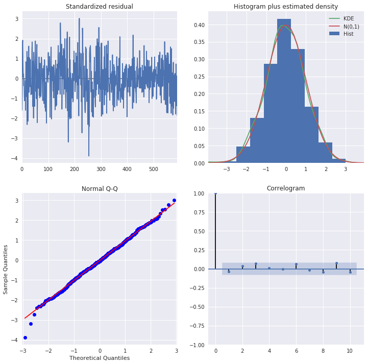

```python
# Summarize residual errors for the automated grid search ARIMA model
print(stepwise_results.summary())
stepwise_results.plot_diagnostics(figsize=(12,12))
plt.show()
```

```python
if notifyStatus: status_notify("ARIMA automated stepwise search completed! "+datetime.now().strftime('%a %B %d, %Y %I:%M:%S %p'))
```

```python
# Do an automated random search of ARIMA parameters
n_fits = int(max_p * max_d * max_q * max_P * max_D * max_Q * 0.30)
if seasonal_freq == 0:
    randgrid_results = pm.auto_arima(train_ts, start_p = start_p, d = start_d, start_q = start_q, max_p = max_p, max_d = max_d, max_q = max_q,
                                     seasonal = False, stepwise = False, random = True, n_fits = n_fits, max_order = None,
                                     trace = True, suppress_warnings = True, random_state = seedNum, error_action="ignore")
else:
    randgrid_results = pm.auto_arima(train_ts, start_p = start_p, d = start_d, start_q = start_q, max_p = max_p, max_d = max_d, max_q = max_q,
                                     seasonal = True, m = seasonal_freq, start_P = start_P, D = start_D, start_Q = start_Q, max_P = max_P, max_D = max_D, max_Q = max_Q,
                                     stepwise = False, random = True, n_fits = n_fits, max_order = None,
                                     trace = True, suppress_warnings = True, random_state = seedNum, error_action="ignore")
```

```
Fit ARIMA(0,0,1)x(0,0,1,12) [intercept=True]; AIC=5201.457, BIC=5218.984, Time=2.432 seconds
Fit ARIMA(2,0,1)x(0,0,1,12) [intercept=True]; AIC=4891.281, BIC=4917.572, Time=4.873 seconds
Fit ARIMA(2,0,3)x(0,0,2,12) [intercept=True]; AIC=4798.361, BIC=4837.797, Time=9.255 seconds
Fit ARIMA(1,0,0)x(1,0,2,12) [intercept=True]; AIC=4579.336, BIC=4605.627, Time=12.805 seconds
Fit ARIMA(4,0,4)x(0,0,2,12) [intercept=True]; AIC=4812.557, BIC=4865.139, Time=23.123 seconds
Fit ARIMA(0,0,3)x(1,0,2,12) [intercept=True]; AIC=4828.585, BIC=4863.640, Time=18.011 seconds
Fit ARIMA(4,0,3)x(1,0,1,12) [intercept=True]; AIC=4709.049, BIC=4757.249, Time=8.670 seconds
Fit ARIMA(0,0,1)x(1,0,1,12) [intercept=True]; AIC=5107.668, BIC=5129.577, Time=4.195 seconds
Fit ARIMA(1,0,1)x(1,0,0,12) [intercept=True]; AIC=4714.553, BIC=4736.462, Time=3.723 seconds
Fit ARIMA(1,0,1)x(2,0,2,12) [intercept=True]; AIC=4551.090, BIC=4586.145, Time=17.926 seconds
Fit ARIMA(0,0,2)x(0,0,0,12) [intercept=True]; AIC=5201.981, BIC=5219.508, Time=1.254 seconds
Fit ARIMA(3,0,0)x(1,0,1,12) [intercept=True]; AIC=4559.342, BIC=4590.014, Time=6.471 seconds
Fit ARIMA(1,0,4)x(1,0,2,12) [intercept=True]; AIC=4544.107, BIC=4587.925, Time=20.670 seconds
Fit ARIMA(1,0,2)x(2,0,0,12) [intercept=True]; AIC=4654.829, BIC=4685.502, Time=13.820 seconds
Fit ARIMA(0,0,0)x(1,0,2,12) [intercept=True]; AIC=5414.945, BIC=5436.854, Time=10.897 seconds
Fit ARIMA(1,0,3)x(2,0,1,12) [intercept=True]; AIC=4738.491, BIC=4777.928, Time=16.353 seconds
Fit ARIMA(4,0,4)x(2,0,1,12) [intercept=True]; AIC=4535.034, BIC=4591.998, Time=23.389 seconds
Fit ARIMA(2,0,1)x(2,0,2,12) [intercept=True]; AIC=4699.087, BIC=4738.523, Time=16.137 seconds
Fit ARIMA(3,0,2)x(1,0,1,12) [intercept=True]; AIC=4695.072, BIC=4734.509, Time=7.504 seconds
Fit ARIMA(1,0,3)x(1,0,2,12) [intercept=True]; AIC=4690.399, BIC=4729.836, Time=18.306 seconds
Fit ARIMA(0,0,2)x(0,0,1,12) [intercept=True]; AIC=5017.221, BIC=5039.130, Time=3.563 seconds
Fit ARIMA(4,0,1)x(2,0,0,12) [intercept=True]; AIC=4658.115, BIC=4697.551, Time=19.382 seconds
Fit ARIMA(2,0,1)x(0,0,2,12) [intercept=True]; AIC=4799.429, BIC=4830.101, Time=13.622 seconds
Fit ARIMA(3,0,4)x(2,0,2,12) [intercept=True]; AIC=4547.823, BIC=4604.787, Time=25.764 seconds
Fit ARIMA(3,0,2)x(0,0,0,12) [intercept=True]; AIC=4940.009, BIC=4970.682, Time=3.237 seconds
Fit ARIMA(2,0,3)x(1,0,0,12) [intercept=True]; AIC=4712.673, BIC=4747.728, Time=5.871 seconds
Fit ARIMA(0,0,1)x(2,0,2,12) [intercept=True]; AIC=5112.818, BIC=5143.490, Time=14.942 seconds
Fit ARIMA(4,0,3)x(2,0,2,12) [intercept=True]; AIC=4652.171, BIC=4709.134, Time=26.218 seconds
Fit ARIMA(1,0,4)x(2,0,0,12) [intercept=True]; AIC=4656.439, BIC=4695.875, Time=15.623 seconds
Fit ARIMA(4,0,4)x(1,0,2,12) [intercept=True]; AIC=4530.149, BIC=4587.113, Time=25.605 seconds
Fit ARIMA(4,0,4)x(0,0,1,12) [intercept=True]; AIC=4859.319, BIC=4907.519, Time=8.882 seconds
Fit ARIMA(1,0,2)x(1,0,1,12) [intercept=True]; AIC=4654.773, BIC=4685.446, Time=6.403 seconds
Fit ARIMA(4,0,0)x(1,0,2,12) [intercept=True]; AIC=4546.070, BIC=4585.506, Time=16.730 seconds
Fit ARIMA(3,0,1)x(1,0,2,12) [intercept=True]; AIC=4586.632, BIC=4626.068, Time=18.226 seconds
Fit ARIMA(1,0,1)x(0,0,2,12) [intercept=True]; AIC=4798.817, BIC=4825.108, Time=6.574 seconds
Fit ARIMA(1,0,3)x(0,0,1,12) [intercept=True]; AIC=4870.357, BIC=4901.030, Time=4.106 seconds
Fit ARIMA(0,0,1)x(2,0,0,12) [intercept=True]; AIC=5130.885, BIC=5152.794, Time=12.088 seconds
Fit ARIMA(4,0,3)x(1,0,0,12) [intercept=True]; AIC=4708.416, BIC=4752.234, Time=7.518 seconds
Total fit time: 474.192 seconds
```

```
                                        SARIMAX Results
===============================================================================================
Dep. Variable:                                       y   No. Observations:                  591
Model:             SARIMAX(4, 0, 4)x(1, 0, [1, 2], 12)   Log Likelihood               -2252.075
Date:                                 Mon, 24 Aug 2020   AIC                           4530.149
Time:                                         03:33:06   BIC                           4587.113
Sample:                                              0   HQIC                          4552.339
                                                 - 591
Covariance Type:                                   opg
==============================================================================
                 coef    std err          z      P>|z|      [0.025      0.975]
------------------------------------------------------------------------------
intercept      0.0852      0.199      0.429      0.668      -0.304       0.475
ar.L1         -1.1629      0.021    -55.175      0.000      -1.204      -1.122
ar.L2         -0.0481      0.027     -1.772      0.076      -0.101       0.005
ar.L3          1.0888      0.027     39.733      0.000       1.035       1.143
ar.L4          0.9457      0.020     46.498      0.000       0.906       0.986
ma.L1          1.8426      0.039     47.426      0.000       1.766       1.919
ma.L2          1.4811      0.079     18.852      0.000       1.327       1.635
ma.L3          0.3549      0.077      4.591      0.000       0.203       0.506
ma.L4         -0.2795      0.038     -7.335      0.000      -0.354      -0.205
ar.S.L12       0.9960      0.002    424.734      0.000       0.991       1.001
ma.S.L12      -0.7923      0.042    -18.986      0.000      -0.874      -0.710
ma.S.L24      -0.0870      0.044     -1.989      0.047      -0.173      -0.001
sigma2       112.1780      6.498     17.263      0.000      99.442     124.914
===================================================================================
Ljung-Box (Q):                       60.14   Jarque-Bera (JB):                 2.43
Prob(Q):                              0.02   Prob(JB):                         0.30
Heteroskedasticity (H):               0.57   Skew:                            -0.12
Prob(H) (two-sided):                  0.00   Kurtosis:                         3.20
===================================================================================

Warnings:
[1] Covariance matrix calculated using the outer product of gradients (complex-step).
```

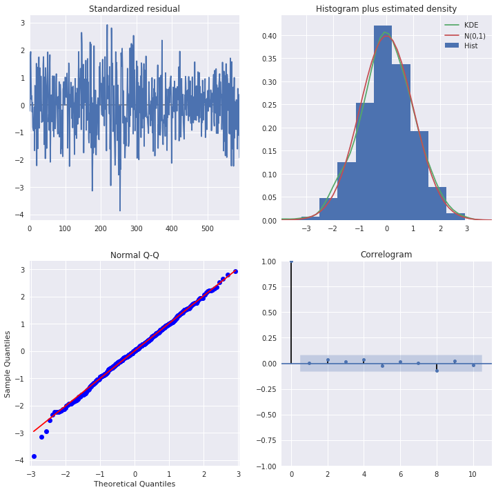

```python
# Summarize residual errors for the automated grid search ARIMA model
print(randgrid_results.summary())
randgrid_results.plot_diagnostics(figsize=(12,12))
plt.show()
```

```python
if notifyStatus: status_notify("ARIMA automated random search completed! "+datetime.now().strftime('%a %B %d, %Y %I:%M:%S %p'))
```

```python
# Do an automated grid search of ARIMA parameters
if (seasonal_freq == 0):
    autogrid_results = pm.auto_arima(train_ts, start_p = start_p, d = start_d, start_q = start_q, max_p = max_p, max_d = max_d, max_q = max_q,
                                     seasonal = False, stepwise = False, max_order = None, trace = True, suppress_warnings = True, random_state = seedNum, error_action="ignore")
else:
    autogrid_results = pm.auto_arima(train_ts, start_p = start_p, d = start_d, start_q = start_q, max_p = max_p, max_d = max_d, max_q = max_q,
                                     seasonal = True, m = seasonal_freq, start_P = start_P, D = start_D, start_Q = start_Q, max_P = max_P, max_D = max_D, max_Q = max_Q,
                                     stepwise = False, max_order = None, trace = True, suppress_warnings = True, random_state = seedNum, error_action="ignore")
```

```
Fit ARIMA(0,0,0)x(0,0,0,12) [intercept=True]; AIC=5877.549, BIC=5886.313, Time=0.251 seconds
Fit ARIMA(0,0,0)x(0,0,1,12) [intercept=True]; AIC=5546.148, BIC=5559.293, Time=0.814 seconds
Fit ARIMA(0,0,0)x(0,0,2,12) [intercept=True]; AIC=5431.123, BIC=5448.651, Time=3.546 seconds
Fit ARIMA(0,0,0)x(1,0,0,12) [intercept=True]; AIC=5458.140, BIC=5471.286, Time=1.577 seconds
Fit ARIMA(0,0,0)x(1,0,1,12) [intercept=True]; AIC=5881.445, BIC=5898.973, Time=1.488 seconds
Fit ARIMA(0,0,0)x(1,0,2,12) [intercept=True]; AIC=5414.945, BIC=5436.854, Time=10.891 seconds
Fit ARIMA(0,0,0)x(2,0,0,12) [intercept=True]; AIC=5424.435, BIC=5441.962, Time=10.193 seconds
Fit ARIMA(0,0,0)x(2,0,1,12) [intercept=True]; AIC=5469.637, BIC=5491.546, Time=10.955 seconds
Fit ARIMA(0,0,0)x(2,0,2,12) [intercept=True]; AIC=5432.122, BIC=5458.413, Time=13.537 seconds
Fit ARIMA(0,0,1)x(0,0,0,12) [intercept=True]; AIC=5394.223, BIC=5407.369, Time=0.641 seconds
Fit ARIMA(0,0,1)x(0,0,1,12) [intercept=True]; AIC=5201.457, BIC=5218.984, Time=2.474 seconds
Fit ARIMA(0,0,1)x(0,0,2,12) [intercept=True]; AIC=5107.193, BIC=5129.102, Time=3.606 seconds
Fit ARIMA(0,0,1)x(1,0,0,12) [intercept=True]; AIC=5107.299, BIC=5124.826, Time=2.557 seconds
Fit ARIMA(0,0,1)x(1,0,1,12) [intercept=True]; AIC=5107.668, BIC=5129.577, Time=4.166 seconds
Fit ARIMA(0,0,1)x(1,0,2,12) [intercept=True]; AIC=5101.198, BIC=5127.489, Time=11.896 seconds
Fit ARIMA(0,0,1)x(2,0,0,12) [intercept=True]; AIC=5130.885, BIC=5152.794, Time=12.097 seconds
Fit ARIMA(0,0,1)x(2,0,1,12) [intercept=True]; AIC=5129.626, BIC=5155.917, Time=12.170 seconds
Fit ARIMA(0,0,1)x(2,0,2,12) [intercept=True]; AIC=5112.818, BIC=5143.490, Time=15.069 seconds
Fit ARIMA(0,0,2)x(0,0,0,12) [intercept=True]; AIC=5201.981, BIC=5219.508, Time=1.232 seconds
Fit ARIMA(0,0,2)x(0,0,1,12) [intercept=True]; AIC=5017.221, BIC=5039.130, Time=3.474 seconds
Fit ARIMA(0,0,2)x(0,0,2,12) [intercept=True]; AIC=4944.558, BIC=4970.849, Time=8.295 seconds
Fit ARIMA(0,0,2)x(1,0,0,12) [intercept=True]; AIC=4936.405, BIC=4958.314, Time=3.491 seconds
Fit ARIMA(0,0,2)x(1,0,1,12) [intercept=True]; AIC=4940.080, BIC=4966.371, Time=6.080 seconds
Fit ARIMA(0,0,2)x(1,0,2,12) [intercept=True]; AIC=4939.703, BIC=4970.376, Time=16.406 seconds
Fit ARIMA(0,0,2)x(2,0,0,12) [intercept=True]; AIC=4941.633, BIC=4967.924, Time=13.098 seconds
Fit ARIMA(0,0,2)x(2,0,1,12) [intercept=True]; AIC=4952.548, BIC=4983.221, Time=14.359 seconds
Fit ARIMA(0,0,2)x(2,0,2,12) [intercept=True]; AIC=4942.677, BIC=4977.731, Time=17.766 seconds
Fit ARIMA(0,0,3)x(0,0,0,12) [intercept=True]; AIC=5039.216, BIC=5061.125, Time=1.374 seconds
Fit ARIMA(0,0,3)x(0,0,1,12) [intercept=True]; AIC=4913.383, BIC=4939.674, Time=4.319 seconds
Fit ARIMA(0,0,3)x(0,0,2,12) [intercept=True]; AIC=4856.402, BIC=4887.075, Time=11.473 seconds
Fit ARIMA(0,0,3)x(1,0,0,12) [intercept=True]; AIC=4834.610, BIC=4860.901, Time=4.285 seconds
Fit ARIMA(0,0,3)x(1,0,1,12) [intercept=True]; AIC=4826.623, BIC=4857.296, Time=5.260 seconds
Fit ARIMA(0,0,3)x(1,0,2,12) [intercept=True]; AIC=4828.585, BIC=4863.640, Time=17.764 seconds
Fit ARIMA(0,0,3)x(2,0,0,12) [intercept=True]; AIC=5006.321, BIC=5036.994, Time=12.882 seconds
Fit ARIMA(0,0,3)x(2,0,1,12) [intercept=True]; AIC=4843.266, BIC=4878.320, Time=13.806 seconds
Fit ARIMA(0,0,3)x(2,0,2,12) [intercept=True]; AIC=4866.324, BIC=4905.760, Time=19.244 seconds
Fit ARIMA(0,0,4)x(0,0,0,12) [intercept=True]; AIC=5018.447, BIC=5044.738, Time=1.920 seconds
Fit ARIMA(0,0,4)x(0,0,1,12) [intercept=True]; AIC=4881.471, BIC=4912.144, Time=5.361 seconds
Fit ARIMA(0,0,4)x(0,0,2,12) [intercept=True]; AIC=4827.335, BIC=4862.389, Time=11.861 seconds
Fit ARIMA(0,0,4)x(1,0,0,12) [intercept=True]; AIC=4977.036, BIC=5007.708, Time=5.111 seconds
```

[output cut: 171 more lines]

```
Fit ARIMA(4,0,3)x(1,0,1,12) [intercept=True]; AIC=4709.049, BIC=4757.249, Time=9.228 seconds
Fit ARIMA(4,0,3)x(1,0,2,12) [intercept=True]; AIC=4678.106, BIC=4730.688, Time=23.649 seconds
Fit ARIMA(4,0,3)x(2,0,0,12) [intercept=True]; AIC=4730.408, BIC=4778.608, Time=22.062 seconds
Fit ARIMA(4,0,3)x(2,0,1,12) [intercept=True]; AIC=4729.277, BIC=4781.859, Time=27.292 seconds
Fit ARIMA(4,0,3)x(2,0,2,12) [intercept=True]; AIC=4652.171, BIC=4709.134, Time=27.247 seconds
Fit ARIMA(4,0,4)x(0,0,0,12) [intercept=True]; AIC=4985.796, BIC=5029.614, Time=5.197 seconds
Fit ARIMA(4,0,4)x(0,0,1,12) [intercept=True]; AIC=4859.319, BIC=4907.519, Time=9.568 seconds
Fit ARIMA(4,0,4)x(0,0,2,12) [intercept=True]; AIC=4812.557, BIC=4865.139, Time=24.354 seconds
Fit ARIMA(4,0,4)x(1,0,0,12) [intercept=True]; AIC=4695.789, BIC=4743.989, Time=7.870 seconds
Fit ARIMA(4,0,4)x(1,0,1,12) [intercept=True]; AIC=4531.426, BIC=4584.008, Time=11.104 seconds
Fit ARIMA(4,0,4)x(1,0,2,12) [intercept=True]; AIC=4530.149, BIC=4587.113, Time=26.945 seconds
Fit ARIMA(4,0,4)x(2,0,0,12) [intercept=True]; AIC=4648.159, BIC=4700.741, Time=25.022 seconds
Fit ARIMA(4,0,4)x(2,0,1,12) [intercept=True]; AIC=4535.034, BIC=4591.998, Time=24.906 seconds
Fit ARIMA(4,0,4)x(2,0,2,12) [intercept=True]; AIC=4536.086, BIC=4597.431, Time=30.888 seconds
Total fit time: 2715.271 seconds
```

```
                                        SARIMAX Results
===============================================================================================
Dep. Variable:                                       y   No. Observations:                  591
Model:             SARIMAX(4, 0, 4)x(1, 0, [1, 2], 12)   Log Likelihood               -2252.075
Date:                                 Mon, 24 Aug 2020   AIC                           4530.149
Time:                                         04:18:23   BIC                           4587.113
Sample:                                              0   HQIC                          4552.339
                                                 - 591
Covariance Type:                                   opg
==============================================================================
                 coef    std err          z      P>|z|      [0.025      0.975]
------------------------------------------------------------------------------
intercept      0.0852      0.199      0.429      0.668      -0.304       0.475
ar.L1         -1.1629      0.021    -55.175      0.000      -1.204      -1.122
ar.L2         -0.0481      0.027     -1.772      0.076      -0.101       0.005
ar.L3          1.0888      0.027     39.733      0.000       1.035       1.143
ar.L4          0.9457      0.020     46.498      0.000       0.906       0.986
ma.L1          1.8426      0.039     47.426      0.000       1.766       1.919
ma.L2          1.4811      0.079     18.852      0.000       1.327       1.635
ma.L3          0.3549      0.077      4.591      0.000       0.203       0.506
ma.L4         -0.2795      0.038     -7.335      0.000      -0.354      -0.205
ar.S.L12       0.9960      0.002    424.734      0.000       0.991       1.001
ma.S.L12      -0.7923      0.042    -18.986      0.000      -0.874      -0.710
ma.S.L24      -0.0870      0.044     -1.989      0.047      -0.173      -0.001
sigma2       112.1780      6.498     17.263      0.000      99.442     124.914
===================================================================================
Ljung-Box (Q):                       60.14   Jarque-Bera (JB):                 2.43
Prob(Q):                              0.02   Prob(JB):                         0.30
Heteroskedasticity (H):               0.57   Skew:                            -0.12
Prob(H) (two-sided):                  0.00   Kurtosis:                         3.20
===================================================================================

Warnings:
[1] Covariance matrix calculated using the outer product of gradients (complex-step).
```

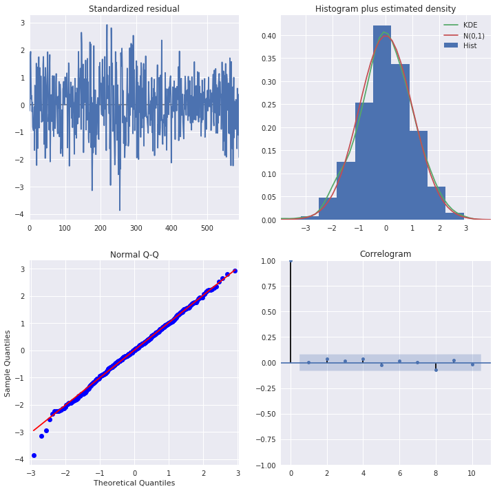

```python
# Summarize residual errors for the automated grid search ARIMA model
print(autogrid_results.summary())
autogrid_results.plot_diagnostics(figsize=(12,12))
plt.show()
```

```python
if notifyStatus: status_notify("ARIMA automated grid search completed! "+datetime.now().strftime('%a %B %d, %Y %I:%M:%S %p'))
```

```python
# Not applicable for this iteration of the project

# Set up the function to handle the ARIMA calculation
# def Calculate_ARIMA(ns_order, ss_order):
#     startTimeModel = datetime.now()
#     aic_score, bic_score = float("inf"), float("inf")
#     if (verbose): print('Trying to fit the model with parameters:', ns_order, ss_order)
#     try:
#         if (ss_order[3] == 0): grid_model = SARIMAX(train_ts, order=ns_order)
#         else: grid_model = SARIMAX(train_ts, order=ns_order, seasonal_order=ss_order)
#         with warnings.catch_warnings():
#             warnings.simplefilter("ignore")
#             grid_results = grid_model.fit(disp = False)
#         aic_score = grid_results.aic
#         bic_score = grid_results.bic
#         if (verbose): print('Fit ARIMA: order=%s seasonal_order=%s; AIC=%.3f, BIC=%.3f, Fit time=%s' %
#               (ns_order, ss_order, aic_score, bic_score, (datetime.now() - startTimeModel)))
#         return(aic_score, bic_score)
#     except:
#         return(float("inf"), float("inf"))
```

```python
# Not applicable for this iteration of the project

# Do a manual grid search of ARIMA parameters
# best_score, best_ns_cfg, best_ss_cfg = float("inf"), None, None
# for p in range(start_p, max_p+1):
#     for d in range(start_d, max_d+1):
#         for q in range(start_q, max_q+1):
#             for P in range(start_P, max_P+1):
#                 for D in range(start_D, max_D+1):
#                     for Q in range(start_Q, max_Q+1):
#                         ns_order = (p, d, q)
#                         ss_order = (P, D, Q, seasonal_freq)
#                         aic_score, bic_score = Calculate_ARIMA(ns_order, ss_order)
#                         if (aic_score < best_score):
#                             best_ns_cfg, best_ss_cfg, best_score = ns_order, ss_order, aic_score
#                             print('A better model found: order=%s seasonal_order=%s; AIC=%.3f, BIC=%.3f' % (ns_order, ss_order, aic_score, bic_score))
# print('Best ARIMA model via manual search: order=%s seasonal_order=%s; AIC=%f' % (best_ns_cfg, best_ss_cfg, best_score))
```

```python
# Summarize residual errors for the manual ARIMA model
# manual_model = SARIMAX(train_ts, order=best_ns_cfg, seasonal_order=best_ss_cfg)
# manual_results = manual_model.fit(disp = False)
# print(manual_results.summary())
# manual_results.plot_diagnostics(figsize=(12,12))
# plt.show()
```

```python
if notifyStatus: status_notify("ARIMA Hyperparameters Search completed! "+datetime.now().strftime('%a %B %d, %Y %I:%M:%S %p'))
```

### 4.c) Evaluate the Residual Errors

A good final check of a model is to review residual forecast errors. Ideally, the distribution of residual errors should be a Gaussian with a zero mean.

```python
# Set the ARIMA order parameters for validation and forecasting
# final_ns_order = stepwise_results.order
final_ns_order = randgrid_results.order
# final_ns_order = autogrid_results.order
# final_ns_order = best_ns_cfg
if seasonal_freq != 0:
#     final_ss_order = stepwise_results.seasonal_order
    final_ss_order = randgrid_results.seasonal_order
#     final_ss_order = autogrid_results.seasonal_order
#     final_ss_order = best_ss_cfg
    print("Final Non-season order:", final_ns_order, 'Final Seasonal Order:', final_ss_order)
else:
    print("Final Non-season order:", final_ns_order)
```

```
Final Non-season order: (4, 0, 4) Final Seasonal Order: (1, 0, 2, 12)
```

```
                                        SARIMAX Results
===============================================================================================
Dep. Variable:                                   value   No. Observations:                  739
Model:             SARIMAX(4, 0, 4)x(1, 0, [1, 2], 12)   Log Likelihood               -2793.870
Date:                                 Mon, 24 Aug 2020   AIC                           5611.739
Time:                                         04:18:59   BIC                           5667.003
Sample:                                     01-01-1959   HQIC                          5633.048
                                          - 07-01-2020
Covariance Type:                                   opg
==============================================================================
                 coef    std err          z      P>|z|      [0.025      0.975]
------------------------------------------------------------------------------
ar.L1          0.0473      0.075      0.634      0.526      -0.099       0.193
ar.L2          0.0490      0.066      0.739      0.460      -0.081       0.179
ar.L3         -0.0365      0.068     -0.536      0.592      -0.170       0.097
ar.L4          0.8281      0.063     13.083      0.000       0.704       0.952
ma.L1          0.6260      0.080      7.873      0.000       0.470       0.782
ma.L2          0.5797      0.090      6.419      0.000       0.403       0.757
ma.L3          0.6326      0.053     11.927      0.000       0.529       0.737
ma.L4         -0.3069      0.038     -8.182      0.000      -0.380      -0.233
ar.S.L12       0.9936      0.003    360.985      0.000       0.988       0.999
ma.S.L12      -0.7099      0.039    -18.122      0.000      -0.787      -0.633
ma.S.L24      -0.1292      0.040     -3.218      0.001      -0.208      -0.051
sigma2       108.3145      5.167     20.963      0.000      98.187     118.442
===================================================================================
Ljung-Box (Q):                       57.34   Jarque-Bera (JB):                13.31
Prob(Q):                              0.04   Prob(JB):                         0.00
Heteroskedasticity (H):               0.60   Skew:                            -0.15
Prob(H) (two-sided):                  0.00   Kurtosis:                         3.58
===================================================================================

Warnings:
[1] Covariance matrix calculated using the outer product of gradients (complex-step).
```

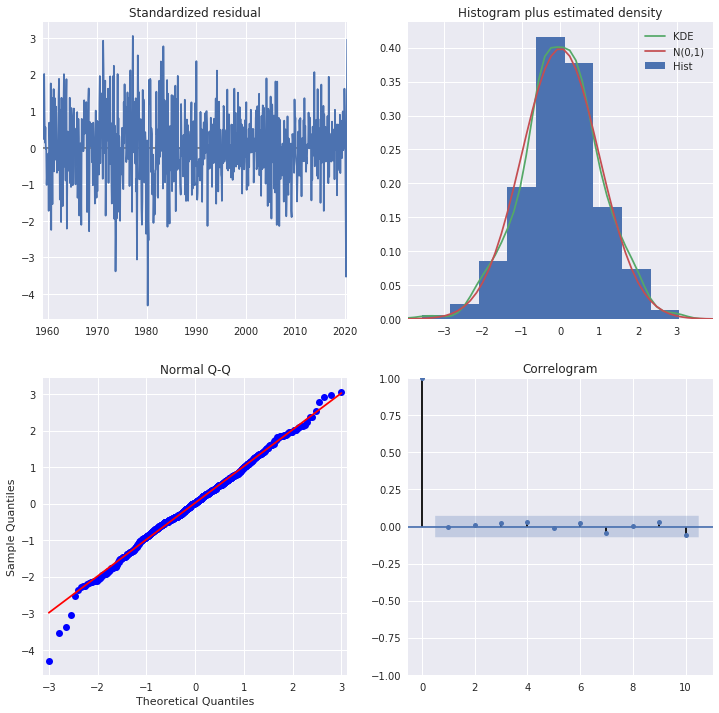

```python
# Summarize residual errors for the final ARIMA model
if seasonal_freq != 0:
    final_model = SARIMAX(time_series, order=final_ns_order, seasonal_order=final_ss_order)
else:
    final_model = SARIMAX(time_series, order=final_ns_order)
final_results = final_model.fit(disp = False)
print(final_results.summary())
final_results.plot_diagnostics(figsize=(12,12))
plt.show()
```

```python
if notifyStatus: status_notify("ARIMA Task 4: Fit and Evaluate Models completed! "+datetime.now().strftime('%a %B %d, %Y %I:%M:%S %p'))
```

## Section 5. Finalize Model and Make Predictions

```python
if notifyStatus: status_notify("ARIMA Task 5: Finalize Model and Make Predictions has begun! "+datetime.now().strftime('%a %B %d, %Y %I:%M:%S %p'))
```

### 5.a) Validation via In-sample Data

```python
validate_forecast = final_results.get_prediction(start = -test_size)
mean_validate_forecast = validate_forecast.predicted_mean
validate_confidence_intervals = validate_forecast.conf_int()
```

```python
# Occasionally some predicted values turned out to be < 0 but they should not be (e.g. rainfall, disease cases, etc.)
# If we have those values, we will need to set them to 0
# print(mean_validate_forecast[mean_validate_forecast < 0])
# mean_validate_forecast[mean_validate_forecast < 0] = 0
```

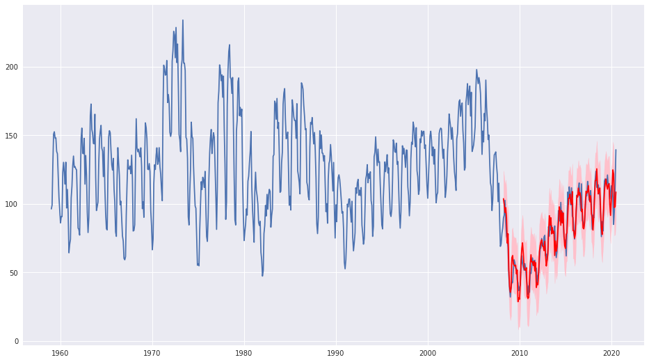

```python
plt.figure(figsize=(16,9))
plt.plot(time_series.index, time_series[target_col], label='observed')
plt.plot(mean_validate_forecast.index, mean_validate_forecast.values, color='red', label='forecast')
plt.fill_between(validate_confidence_intervals.index, validate_confidence_intervals[lower_bound],
                 validate_confidence_intervals[upper_bound], color='pink')
plt.show()
```

```python
# Evaluate RMSE for the validation data
y_test = time_series[-test_size:]
predictions = mean_validate_forecast.values
for i in range(y_test.shape[0]):
    print(y_test.index[i], ' | ', y_test.iloc[i,0], ' | ', predictions[i])
print('RMSE from the validation data is: %.3f' % math.sqrt(mean_squared_error(y_test, predictions)))
```

```
2008-04-01 00:00:00  |  89.5  |  103.6893939390626
2008-05-01 00:00:00  |  91.7  |  99.51526402917918
2008-06-01 00:00:00  |  102.5  |  93.53975391695995
2008-07-01 00:00:00  |  86.7  |  97.08976588339712
2008-08-01 00:00:00  |  76.4  |  89.77870868457582
2008-09-01 00:00:00  |  73.9  |  71.24035348682207
2008-10-01 00:00:00  |  68.2  |  78.03021476921376
2008-11-01 00:00:00  |  47.5  |  51.813052085302196
2008-12-01 00:00:00  |  37.7  |  39.66808913110144
2009-01-01 00:00:00  |  31.9  |  35.3781045233315
2009-02-01 00:00:00  |  39.8  |  38.579060047653435
2009-03-01 00:00:00  |  42.7  |  60.6324653127758
2009-04-01 00:00:00  |  42.5  |  62.210978678217096
2009-05-01 00:00:00  |  52.2  |  56.12490575166936
2009-06-01 00:00:00  |  59.1  |  55.15775019556664
2009-07-01 00:00:00  |  56.8  |  54.53842801216205
2009-08-01 00:00:00  |  52.9  |  55.130383338794445
2009-09-01 00:00:00  |  52.6  |  48.79671048100998
2009-10-01 00:00:00  |  44.5  |  51.61435107478398
2009-11-01 00:00:00  |  42.3  |  28.51474708584647
2009-12-01 00:00:00  |  36.6  |  31.22208059713953
2010-01-01 00:00:00  |  38.9  |  30.304386092583638
2010-02-01 00:00:00  |  40.7  |  42.22150886507352
2010-03-01 00:00:00  |  54.7  |  58.472126682009346
2010-04-01 00:00:00  |  62.0  |  67.17823732246084
2010-05-01 00:00:00  |  56.2  |  71.46359119611677
2010-06-01 00:00:00  |  53.8  |  63.57208086275647
2010-07-01 00:00:00  |  51.5  |  53.56782851734211
2010-08-01 00:00:00  |  56.3  |  51.674746028700284
2010-09-01 00:00:00  |  53.0  |  51.37637784647264
2010-10-01 00:00:00  |  45.4  |  53.31085005981559
2010-11-01 00:00:00  |  40.6  |  32.585963386945444
2010-12-01 00:00:00  |  33.8  |  30.84456159757772
2011-01-01 00:00:00  |  40.2  |  31.718779179126138
2011-02-01 00:00:00  |  35.4  |  43.48020527593252
2011-03-01 00:00:00  |  49.9  |  55.24088007449548
2011-04-01 00:00:00  |  49.0  |  62.7996148250593
2011-05-01 00:00:00  |  54.0  |  57.498045299039916
2011-06-01 00:00:00  |  60.5  |  57.66657775083455
2011-07-01 00:00:00  |  57.6  |  55.02318221800153
```

[output cut: 94 more lines]

```
2019-06-01 00:00:00  |  115.1  |  118.01942367499194
2019-07-01 00:00:00  |  114.2  |  113.23215977932321
2019-08-01 00:00:00  |  121.0  |  110.6251878600114
2019-09-01 00:00:00  |  113.2  |  113.88652929024462
2019-10-01 00:00:00  |  114.8  |  114.58790770955474
2019-11-01 00:00:00  |  103.4  |  99.81693992167715
2019-12-01 00:00:00  |  108.3  |  91.45398623028078
2020-01-01 00:00:00  |  113.1  |  103.27657374851948
2020-02-01 00:00:00  |  111.6  |  111.1919011224133
2020-03-01 00:00:00  |  104.5  |  124.73226955233336
2020-04-01 00:00:00  |  84.9  |  121.59749604282483
2020-05-01 00:00:00  |  95.1  |  97.21214166453898
2020-06-01 00:00:00  |  114.6  |  98.01358154335881
2020-07-01 00:00:00  |  139.4  |  108.50882487817992
RMSE from the validation data is: 8.763
```

### 5.b) Forecasting Out-of-Sample Data

```python
if seasonal_freq != 0:
    forecast_size = seasonal_freq
else:
    forecast_size = 1
final_forecast = final_results.get_forecast(steps = forecast_size)
mean_final_forecast = final_forecast.predicted_mean
final_confidence_intervals = final_forecast.conf_int()
print("The forecasted values are:\n\n", mean_final_forecast)
```

```
The forecasted values are:

 2020-08-01    128.762128
2020-09-01    123.243186
2020-10-01    123.311379
2020-11-01    108.811160
2020-12-01    105.708496
2021-01-01    104.952179
2021-02-01    105.362738
2021-03-01    111.638604
2021-04-01    115.599476
2021-05-01    118.195137
2021-06-01    124.129767
2021-07-01    128.434039
Freq: MS, dtype: float64
```

```python
# Occasionally some predicted values turned out to be < 0 but they should not be (e.g. rainfall, disease cases, etc.)
# If we have those values, we will need to set them to 0
# print(mean_final_forecast[mean_final_forecast < 0])
# mean_final_forecast[mean_final_forecast < 0] = 0
```

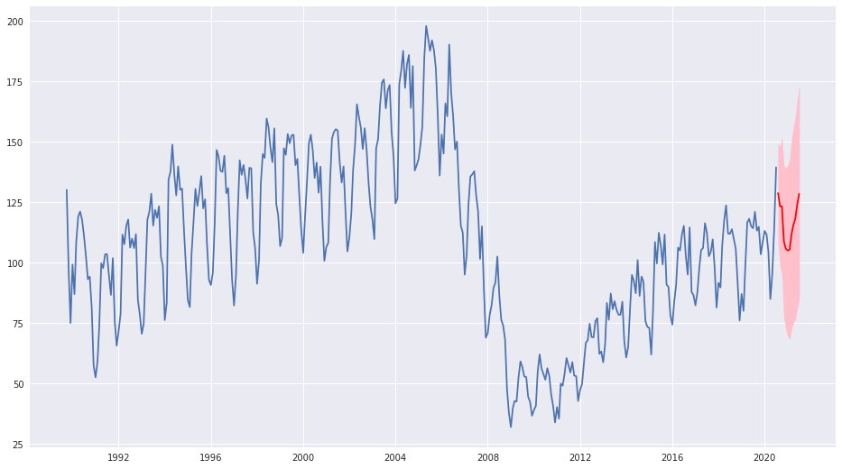

```python
plt.figure(figsize=(16,9))
halfway_point = int(time_series.index.size / 2)
plt.plot(time_series.index[halfway_point:], time_series[target_col][halfway_point:], label='observed')
plt.plot(mean_final_forecast.index, mean_final_forecast.values, color='red', label='forecast')
plt.fill_between(final_confidence_intervals.index, final_confidence_intervals[lower_bound],
                 final_confidence_intervals[upper_bound], color='pink')
plt.show()
```

```python
if notifyStatus: status_notify("ARIMA Task 5: Finalize Model and Make Predictions completed! "+datetime.now().strftime('%a %B %d, %Y %I:%M:%S %p'))
```

```python
print ('Total time for the script:',(datetime.now() - startTimeScript))
```

```
Total time for the script: 1:00:04.771486
```